# Peer-graded Assignment: Learning Machine Course Project

Christian Frei

21 June 2017

## Executive Summary

### Background

Using devices such as Jawbone Up, Nike FuelBand, and Fitbit it is now possible to collect a large amount of data about personal activity relatively inexpensively. These type of devices are part of the quantified self movement – a group of enthusiasts who take measurements about themselves regularly to improve their health, to find patterns in their behavior, or because they are tech geeks. One thing that people regularly do is quantify how much of a particular activity they do, but they rarely quantify how well they do it. In this project, your goal will be to use data from accelerometers on the belt, forearm, arm, and dumbell of 6 participants. They were asked to perform barbell lifts correctly and incorrectly in 5 different ways. More information is available from the website here: http://groupware.les.inf.puc-rio.br/har (see the section on the Weight Lifting Exercise Dataset).

### Data

The training data for this project are available here:

https://d396qusza40orc.cloudfront.net/predmachlearn/pml-training.csv

The test data are available here:

https://d396qusza40orc.cloudfront.net/predmachlearn/pml-testing.csv

The data for this project come from this source: http://groupware.les.inf.puc-rio.br/har. If you use the document you create for this class for any purpose please cite them as they have been very generous in allowing their data to be used for this kind of assignment.

### Goal

The goal of your project is to predict the manner in which they did the exercise. This is the “classe” variable in the training set. You may use any of the other variables to predict with. You should create a report describing how you built your model, how you used cross validation, what you think the expected out of sample error is, and why you made the choices you did. You will also use your prediction model to predict 20 different test cases.

## Download and Load Data

In the beginning of this project, data will be downloaded and load into the memory.

```r
dest.subdirectory <- "./data/"
dest.filename     <- c("pml-training.csv", "pml-testing.csv")
dest.filepath     <- paste0(dest.subdirectory, dest.filename)
source.fileURL    <- c("https://d396qusza40orc.cloudfront.net/predmachlearn/pml-training.csv",
                       "https://d396qusza40orc.cloudfront.net/predmachlearn/pml-testing.csv")

if (!file.exists("data")) {
   dir.create("data")
}

for (download in 1:2) {
   if (!file.exists(dest.filepath[download])){
      download.file(source.fileURL[download], dest.filepath[download], method="curl")
   }
}

pml.training.csv <- read.csv(dest.filepath[1], header=TRUE, sep=",", na.strings=c("NA","#DIV/0!"))
pml.testing.csv <- read.csv(dest.filepath[2], header=TRUE, sep=",", na.strings=c("NA","#DIV/0!"))
```

[output not shown]

```r
pml.training.csv  <- pml.training.csv[,c(-1)]

nzvCol            <- nearZeroVar(pml.training.csv)
pml.training.csv  <- pml.training.csv[, -nzvCol]

uselessColumns    <- c()

for (i in 1:length(pml.training.csv)) {
   if (sum(is.na(pml.training.csv[ , i])) / nrow(pml.training.csv) >= .70) {
      uselessColumns <- rbind(uselessColumns, i)
   }
}

pml.training.csv  <- pml.training.csv[,-uselessColumns]
```

After cleaning training data, validation data (pml.testing.csv) must be brought into the same shape. Therefore, only those columns will be taken over which are included in the training data (pml.training.csv).

```r
usedColumns <- colnames(pml.training.csv)
pml.testing.csv   <- pml.testing.csv[, usedColumns[1:length(usedColumns)-1]]
```

## Data Partitioning

In this step, the training data will be partitioned into training and testing data.

```r
inTrain     <- createDataPartition(pml.training.csv$classe, p=0.6, list=FALSE)
training    <- pml.training.csv[inTrain, ]
testing     <- pml.training.csv[-inTrain, ]
```

The function read.csv loaded data of pml-training.csv & pml-testing.csv. Unfortunately, it often identifies different class for those columns, which are available in both of the loaded data. Therefore, all data of pml-testing.csv have to be converted according to the types of pml-training.csv.

```r
valdiation  <- rbind(training[1, 1:ncol(training)-1], pml.testing.csv)
valdiation  <- valdiation[2:nrow(valdiation), ]
row.names(valdiation) <- 1:nrow(valdiation)
```

## Prediction Model 1: Decision Tree

The first prediction model which will be calculated, is the decision tree.

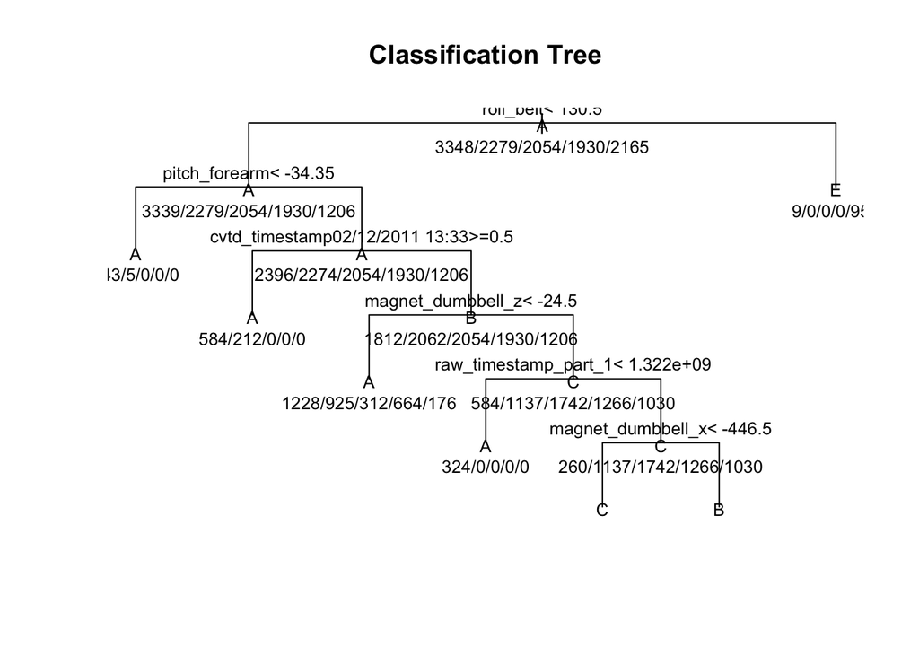

```r
set.seed(12345)

model.rpart <- train(classe ~ ., data=training, method="rpart")

# fancyRpartPlot(model.rpart1)
plot(model.rpart$finalModel, uniform=TRUE, main="Classification Tree")
text(model.rpart$finalModel, use.n=TRUE, all=TRUE, cex=.8)
```

```r
prediction.training.rpart <- predict(model.rpart, newdata = training, method="class")
cm.training.rpart <- confusionMatrix(prediction.training.rpart, training$classe)

prediction.testing.rpart <- predict(model.rpart, newdata = testing, method="class")
cm.testing.rpart <- confusionMatrix(prediction.testing.rpart, testing$classe)
```

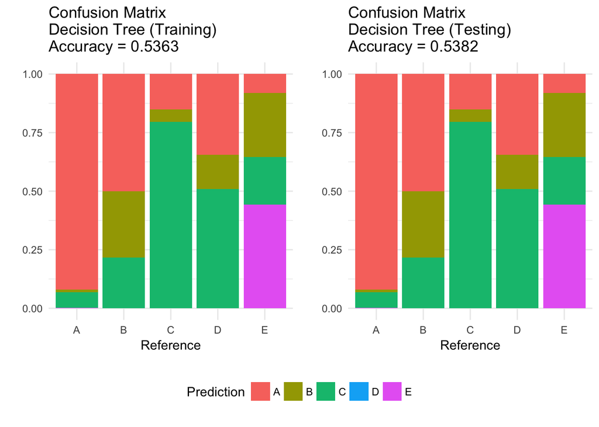

## Prediction Model 2: Random Forest

The second prediction model which will be calculated, is the random forest.

```r
set.seed(12345)

# model.rf <- train(classe ~ ., data=training, method="rf")
model.rf <- randomForest(classe ~ ., data=training)

prediction.training.rf <- predict(model.rf, newdata = training)
cm.training.rf <- confusionMatrix(prediction.training.rf, training$classe)

prediction.testing.rf <- predict(model.rf, newdata = testing)
cm.testing.rf <- confusionMatrix(prediction.testing.rf, testing$classe)
```

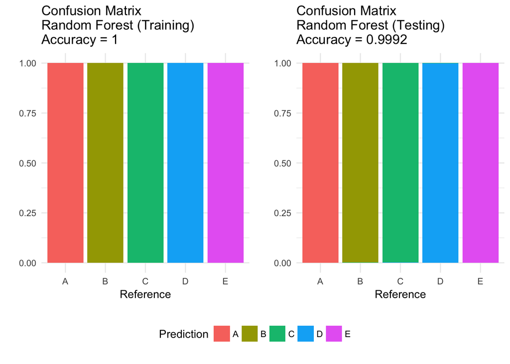

## Prediction Model 3: Generalized Boosted Regression

```r
set.seed(12345)
fitControl <- trainControl(method = "repeatedcv",
                           number = 5,
                           repeats = 1)

model.gbm <- train(classe ~ ., data=training, method = "gbm",
                 trControl = fitControl,
                 verbose = FALSE)


prediction.training.gbm <- predict(model.gbm, newdata = training)
cm.training.gbm <- confusionMatrix(prediction.training.gbm, training$classe)

prediction.testing.gbm <- predict(model.gbm, newdata = testing)
cm.testing.gbm <- confusionMatrix(prediction.testing.gbm, testing$classe)
```

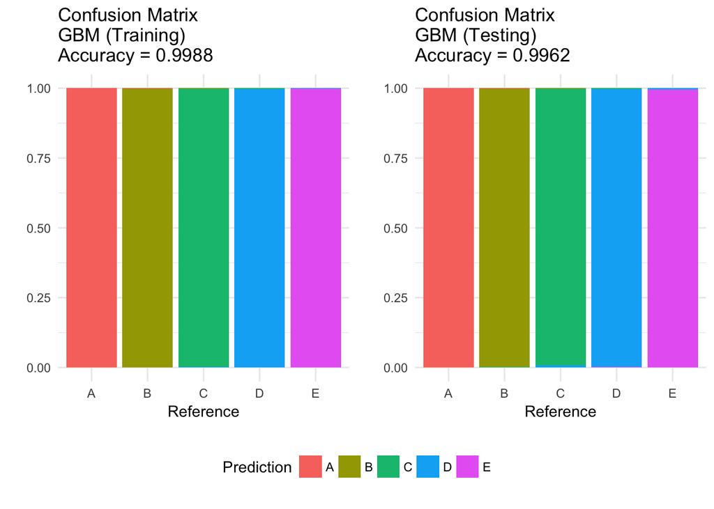

## Conclusion

The random forest and generalized boosted regression are best.

Decision Tree:

- Accuracy: 0.5382
- Out of sample error: 0.4618

Generalized Boosted Regression:

- Accuracy: 0.9962
- Out of sample error: 0.0038

Finally, the model with the highest accuracy and lowest out of sample value will be applied on validation data.

```r
prediction.valdiation.rf <- predict(model.rf, newdata = valdiation)
prediction.valdiation.rf
```

```
##  1  2  3  4  5  6  7  8  9 10 11 12 13 14 15 16 17 18 19 20
##  B  A  B  A  A  E  D  B  A  A  B  C  B  A  E  E  A  B  B  B
## Levels: A B C D E
```

```r
pml_write_files = function(x) {
  n = length(x)
  for (i in 1:n) {
    filename = paste0("problem_id_", i, "_", prediction.valdiation.rf[i], ".txt")
    write.table(x[i], file=filename, quote=FALSE,row.names=FALSE, col.names=FALSE)
  }
}

pml_write_files(prediction.valdiation.rf)
```

# Appendix

## Cleaning the data

```r
str(pml.training.csv)
```

```
## 'data.frame':    19622 obs. of  58 variables:
##  $ user_name           : Factor w/ 6 levels "adelmo","carlitos",..: 2 2 2 2 2 2 2 2 2 2 ...
##  $ raw_timestamp_part_1: int  1323084231 1323084231 1323084231 1323084232 1323084232 1323084232 1323084232 1323084232 1323084232 1323084232 ...
##  $ raw_timestamp_part_2: int  788290 808298 820366 120339 196328 304277 368296 440390 484323 484434 ...
##  $ cvtd_timestamp      : Factor w/ 20 levels "02/12/2011 13:32",..: 9 9 9 9 9 9 9 9 9 9 ...
##  $ num_window          : int  11 11 11 12 12 12 12 12 12 12 ...
##  $ roll_belt           : num  1.41 1.41 1.42 1.48 1.48 1.45 1.42 1.42 1.43 1.45 ...
##  $ pitch_belt          : num  8.07 8.07 8.07 8.05 8.07 8.06 8.09 8.13 8.16 8.17 ...
##  $ yaw_belt            : num  -94.4 -94.4 -94.4 -94.4 -94.4 -94.4 -94.4 -94.4 -94.4 -94.4 ...
##  $ total_accel_belt    : int  3 3 3 3 3 3 3 3 3 3 ...
##  $ gyros_belt_x        : num  0 0.02 0 0.02 0.02 0.02 0.02 0.02 0.02 0.03 ...
##  $ gyros_belt_y        : num  0 0 0 0 0.02 0 0 0 0 0 ...
##  $ gyros_belt_z        : num  -0.02 -0.02 -0.02 -0.03 -0.02 -0.02 -0.02 -0.02 -0.02 0 ...
##  $ accel_belt_x        : int  -21 -22 -20 -22 -21 -21 -22 -22 -20 -21 ...
##  $ accel_belt_y        : int  4 4 5 3 2 4 3 4 2 4 ...
```

[output cut: 44 more lines]

```r
str(pml.testing.csv)
```

```
## 'data.frame':    20 obs. of  57 variables:
##  $ user_name           : Factor w/ 6 levels "adelmo","carlitos",..: 6 5 5 1 4 5 5 5 2 3 ...
##  $ raw_timestamp_part_1: int  1323095002 1322673067 1322673075 1322832789 1322489635 1322673149 1322673128 1322673076 1323084240 1322837822 ...
##  $ raw_timestamp_part_2: int  868349 778725 342967 560311 814776 510661 766645 54671 916313 384285 ...
##  $ cvtd_timestamp      : Factor w/ 11 levels "02/12/2011 13:33",..: 5 10 10 1 6 11 11 10 3 2 ...
##  $ num_window          : int  74 431 439 194 235 504 485 440 323 664 ...
##  $ roll_belt           : num  123 1.02 0.87 125 1.35 -5.92 1.2 0.43 0.93 114 ...
##  $ pitch_belt          : num  27 4.87 1.82 -41.6 3.33 1.59 4.44 4.15 6.72 22.4 ...
##  $ yaw_belt            : num  -4.75 -88.9 -88.5 162 -88.6 -87.7 -87.3 -88.5 -93.7 -13.1 ...
##  $ total_accel_belt    : int  20 4 5 17 3 4 4 4 4 18 ...
##  $ gyros_belt_x        : num  -0.5 -0.06 0.05 0.11 0.03 0.1 -0.06 -0.18 0.1 0.14 ...
##  $ gyros_belt_y        : num  -0.02 -0.02 0.02 0.11 0.02 0.05 0 -0.02 0 0.11 ...
##  $ gyros_belt_z        : num  -0.46 -0.07 0.03 -0.16 0 -0.13 0 -0.03 -0.02 -0.16 ...
##  $ accel_belt_x        : int  -38 -13 1 46 -8 -11 -14 -10 -15 -25 ...
##  $ accel_belt_y        : int  69 11 -1 45 4 -16 2 -2 1 63 ...
```

[output cut: 43 more lines]